# Cellphone Billing Project

Harry Chang

2023-04-22

```r
setwd("/Users/harrychang/Downloads/BT4211/Assignment/Assignment 2")
```

```r
library(readxl)
cellphone = read_excel("cellphone_billing_student.xlsx")
subscriber = read_excel("subscriber_info_student.xlsx")
zip = read_excel("zip_info_student.xlsx")
```

## Exploring the cellphone billing dataset

```r
cellphone
```

```
## # A tibble: 195,878 × 11
##     cust_id bill_year bill_month churn plan_chosen plan1 plan2 plan3 plan4
##       <dbl>     <dbl>      <dbl> <dbl>       <dbl> <dbl> <dbl> <dbl> <dbl>
##  1 19164958      2015          9     0           1     1     0     0     0
##  2 19164958      2015         10     0           1     1     0     0     0
##  3 19164958      2015         11     0           1     1     0     0     0
##  4 19164958      2015         12     0           1     1     0     0     0
##  5 19164958      2016          1     0           1     1     0     0     0
##  6 19164958      2016          2     0           1     1     0     0     0
##  7 19164958      2016          3     0           1     1     0     0     0
##  8 19164958      2016          4     0           1     1     0     0     0
##  9 19164958      2016          5     0           1     1     0     0     0
## 10 19164958      2016          6     0           1     1     0     0     0
## # … with 195,868 more rows, and 2 more variables: total_minute_peak <dbl>,
## #   promo_lag1 <dbl>
```

```r
summary(cellphone)
```

```
##     cust_id           bill_year      bill_month        churn
##  Min.   :19164958   Min.   :2015   Min.   : 1.00   Min.   :0.00000
##  1st Qu.:74944945   1st Qu.:2016   1st Qu.: 3.00   1st Qu.:0.00000
##  Median :81475998   Median :2016   Median : 5.00   Median :0.00000
##  Mean   :81935115   Mean   :2016   Mean   : 5.99   Mean   :0.02508
##  3rd Qu.:88623109   3rd Qu.:2016   3rd Qu.: 9.00   3rd Qu.:0.00000
##  Max.   :88705192   Max.   :2017   Max.   :12.00   Max.   :1.00000
##   plan_chosen        plan1            plan2             plan3
##  Min.   :1.000   Min.   :0.0000   Min.   :0.00000   Min.   :0.0000
##  1st Qu.:1.000   1st Qu.:0.0000   1st Qu.:0.00000   1st Qu.:0.0000
##  Median :1.000   Median :1.0000   Median :0.00000   Median :0.0000
##  Mean   :2.021   Mean   :0.5096   Mean   :0.03194   Mean   :0.3859
##  3rd Qu.:3.000   3rd Qu.:1.0000   3rd Qu.:0.00000   3rd Qu.:1.0000
##  Max.   :4.000   Max.   :1.0000   Max.   :1.00000   Max.   :1.0000
##      plan4         total_minute_peak   promo_lag1
##  Min.   :0.00000   Min.   :   0.0    Min.   :0.0000
##  1st Qu.:0.00000   1st Qu.:  58.0    1st Qu.:0.0000
##  Median :0.00000   Median : 139.0    Median :0.0000
##  Mean   :0.07253   Mean   : 171.4    Mean   :0.1347
##  3rd Qu.:0.00000   3rd Qu.: 244.0    3rd Qu.:0.0000
##  Max.   :1.00000   Max.   :1500.0    Max.   :1.0000
```

### Descriptive statistics

```r
mean_total_minute_peak <- mean(cellphone$total_minute_peak)
median_total_minute_peak <- median(cellphone$total_minute_peak)
sd_total_minute_peak <- sd(cellphone$total_minute_peak)

cat("Mean of total_minute_peak:", mean_total_minute_peak, "\n")
```

```
## Mean of total_minute_peak: 171.4271
```

```r
cat("Median of total_minute_peak:", median_total_minute_peak, "\n")
```

```
## Median of total_minute_peak: 139
```

```r
cat("Standard deviation of total_minute_peak:", sd_total_minute_peak, "\n")
```

```
## Standard deviation of total_minute_peak: 150.8134
```

```r
customer_count <- nrow(cellphone)
plan_proportions <- table(cellphone$plan_chosen) / customer_count
cat("Proportions of customers in each plan:\n")
```

```
## Proportions of customers in each plan:
```

```r
print(plan_proportions)
```

```
##
##          1          2          3          4
## 0.50957739 0.03194335 0.38594942 0.07252984
```

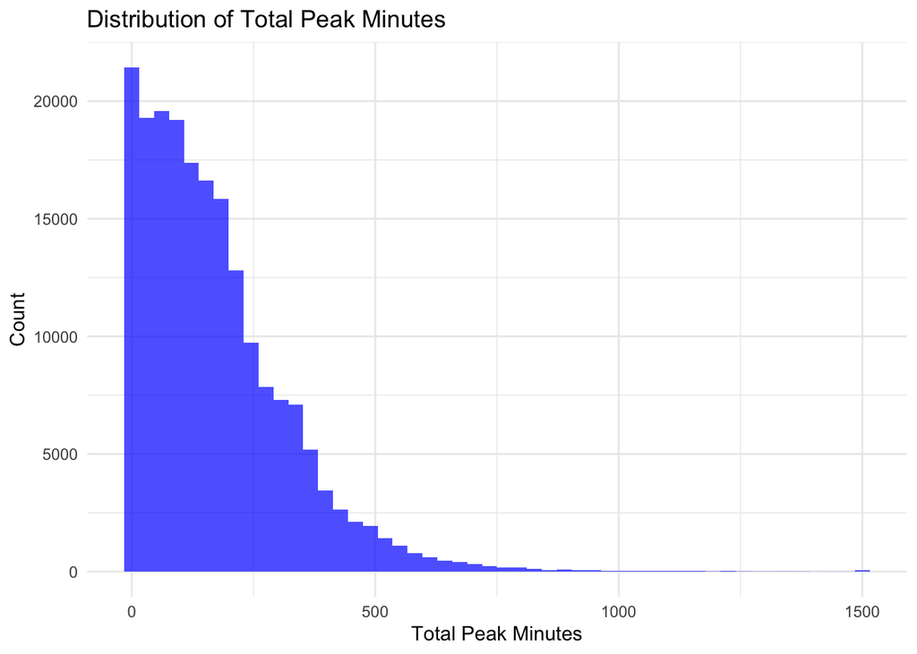

```r
library(ggplot2)
ggplot(cellphone, aes(x = total_minute_peak)) +
  geom_histogram(bins = 50, fill = "blue", alpha = 0.7) +
  theme_minimal() +
  labs(title = "Distribution of Total Peak Minutes", x = "Total Peak Minutes", y = "Count")
```

### Churn analysis

```r
churn_rate_by_plan <- with(cellphone, tapply(churn, plan_chosen, function(x) mean(x == 1)))
cat("Churn rate by plan:\n")
```

```
## Churn rate by plan:
```

```r
print(churn_rate_by_plan)
```

```
##           1           2           3           4
## 0.020257476 0.006233019 0.028174976 0.050749630
```

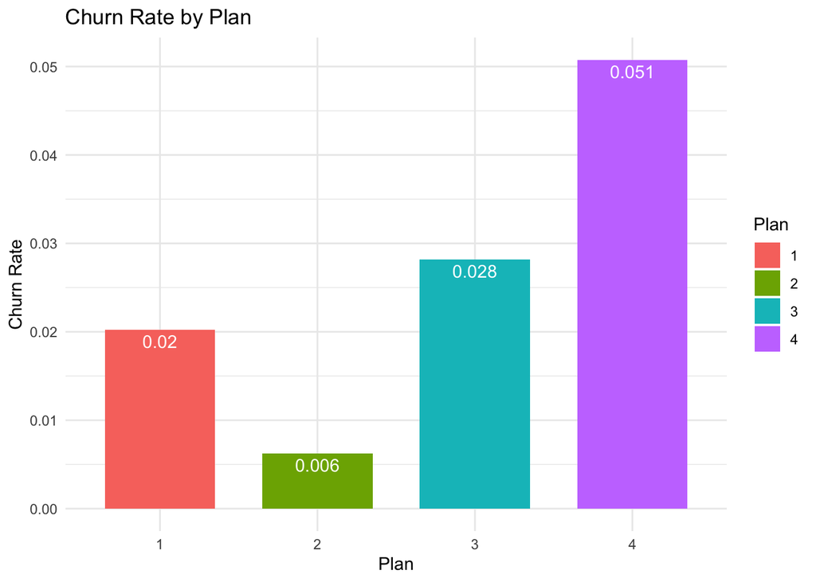

```r
churn_rate_by_plan_df <- as.data.frame(churn_rate_by_plan)
churn_rate_by_plan_df$plan_chosen <- row.names(churn_rate_by_plan_df)

ggplot(churn_rate_by_plan_df, aes(x = plan_chosen, y = churn_rate_by_plan, fill = plan_chosen)) +
  geom_bar(stat = "identity", width = 0.7) +
  theme_minimal() +
  labs(title = "Churn Rate by Plan", x = "Plan", y = "Churn Rate") +
  geom_text(aes(label = round(churn_rate_by_plan,3)), vjust = 1.4, color = "white") +
  scale_fill_discrete(name = "Plan")
```

```r
churn_rate_by_promo <- with(cellphone, tapply(churn, promo_lag1, function(x) mean(x == 1)))
cat("Churn rate by promo_lag1:\n")
```

```
## Churn rate by promo_lag1:
```

```r
print(churn_rate_by_promo)
```

```
##          0          1
## 0.02622635 0.01769476
```

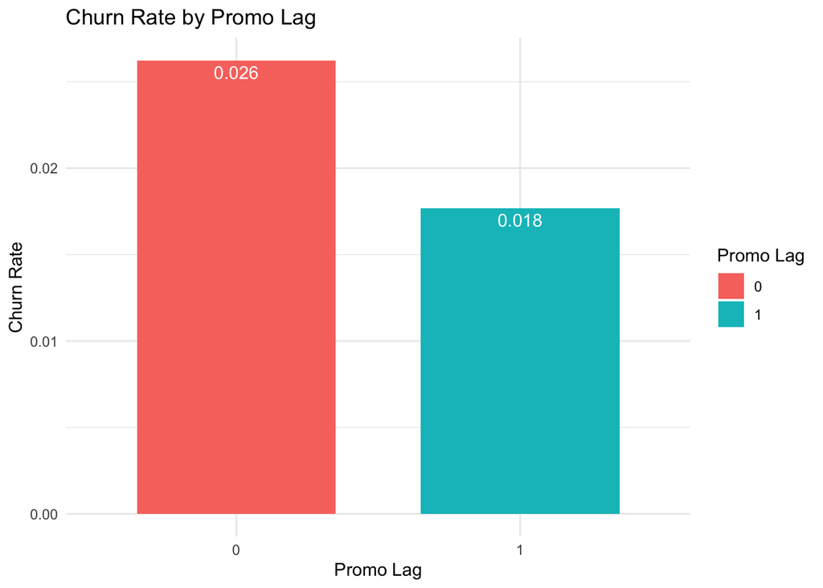

```r
churn_rate_by_promo_df <- as.data.frame(churn_rate_by_promo)
churn_rate_by_promo_df$promo_lag1 <- row.names(churn_rate_by_promo_df)

ggplot(churn_rate_by_promo_df, aes(x = promo_lag1, y = churn_rate_by_promo, fill = promo_lag1)) +
  geom_bar(stat = "identity", width = 0.7) +
  theme_minimal() +
  labs(title = "Churn Rate by Promo Lag", x = "Promo Lag", y = "Churn Rate") +
  geom_text(aes(label = round(churn_rate_by_promo,3)), vjust = 1.4, color = "white") +
  scale_fill_discrete(name = "Promo Lag")
```

### Customer segmentation

```r
library(dplyr)
data_scaled <- cellphone %>%
  select(total_minute_peak, plan_chosen, promo_lag1) %>%
  scale()
```

```r
set.seed(123) # For reproducibility
k <- 3 # Number of clusters
kmeans_result <- kmeans(data_scaled, centers = k)
```

```r
cellphone$cluster <- kmeans_result$cluster
cluster_summary <- cellphone %>%
  group_by(cluster) %>%
  summarise(
    count = n(),
    avg_total_minute_peak = mean(total_minute_peak),
    avg_churn = mean(churn),
    avg_promo_lag1 = mean(promo_lag1),
    plan1_prop = mean(plan1),
    plan2_prop = mean(plan2),
    plan3_prop = mean(plan3),
    plan4_prop = mean(plan4)
  )

cat("Customer segmentation summary:\n")
```

```
## Customer segmentation summary:
```

```r
print(cluster_summary)
```

```
## # A tibble: 3 × 9
##   cluster  count avg_total_minut… avg_churn avg_promo_lag1 plan1_prop plan2_prop
##     <int>  <int>            <dbl>     <dbl>          <dbl>      <dbl>      <dbl>
## 1       1  37530             408.    0.0245          0.144     0.0467     0.0359
## 2       2  55969             124.    0.0361          0.161     0          0.0106
## 3       3 102379             111.    0.0193          0.117     0.958      0.0422
## # … with 2 more variables: plan3_prop <dbl>, plan4_prop <dbl>
```

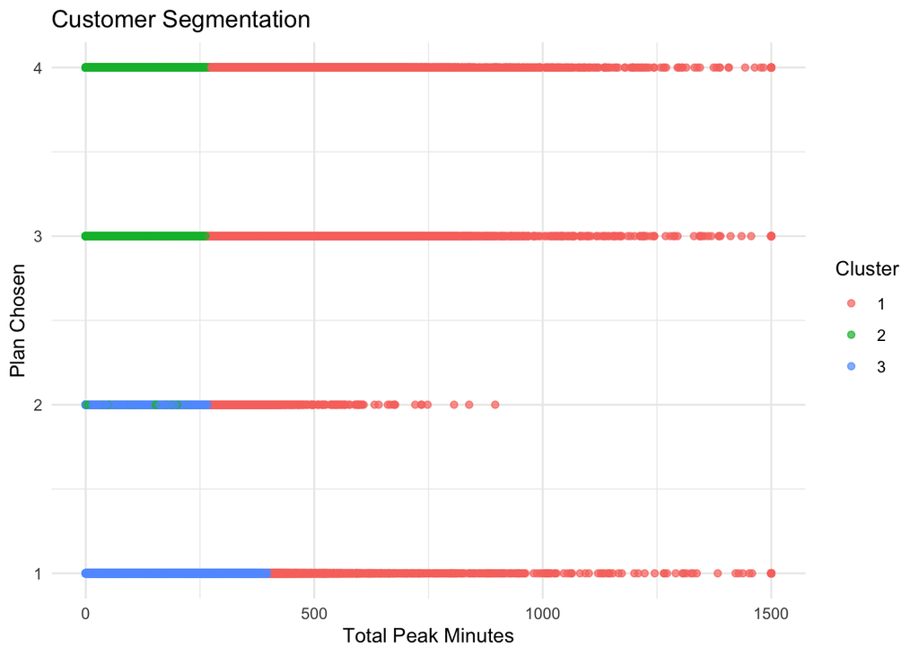

```r
ggplot(cellphone, aes(x = total_minute_peak, y = plan_chosen, color = factor(cluster))) +
  geom_point(alpha = 0.7) +
  theme_minimal() +
  labs(title = "Customer Segmentation", x = "Total Peak Minutes", y = "Plan Chosen", color = "Cluster")
```

### Detailed descriptive analysis

1. How many customers are there for each type of phone service plan?

```r
customers_per_plan <- table(cellphone$plan_chosen)
cat("Number of customers for each plan:\n")
```

```
## Number of customers for each plan:
```

```r
print(customers_per_plan)
```

```
##
##     1     2     3     4
## 99815  6257 75599 14207
```

2. What is the average number of customers acquired for each phone service plan across the months of August to December 2015?

```r
# Filter customers acquired between August and December 2015
data_2015 <- cellphone %>% filter(bill_year == 2015 & bill_month >= 8 & bill_month <= 12)

# Remove duplicate customer IDs and count unique customers per plan
unique_customers_2015 <- data_2015 %>% distinct(cust_id, .keep_all = TRUE)
customers_per_plan_2015 <- table(unique_customers_2015$plan_chosen)

# Calculate the average number of customers acquired per plan
avg_customers_per_plan_2015 <- customers_per_plan_2015 / 5
cat("Average number of customers acquired for each plan (August to December 2015):\n")
```

```
## Average number of customers acquired for each plan (August to December 2015):
```

```r
print(avg_customers_per_plan_2015)
```

```
##
##     1     3     4
## 459.2 853.0  81.2
```

3. What is the average number of months a customer stays with the cellular phone service company from the start till the end of a phone service subscription (i.e., only focus on customers who churned)?

```r
churned_customers <- cellphone %>% filter(churn == 1)
churned_customers_months <- churned_customers %>% group_by(cust_id) %>% summarise(months_active = n())
avg_months_churned <- mean(churned_customers_months$months_active)
cat("Average number of months a churned customer stays with the company:", avg_months_churned, "\n")
```

```
## Average number of months a churned customer stays with the company: 1
```

4. For each type of phone service plan, what is the number of customers who churned?

```r
churned_by_plan <- table(churned_customers$plan_chosen)
cat("Number of churned customers by plan:\n")
```

```
## Number of churned customers by plan:
```

```r
print(churned_by_plan)
```

```
##
##    1    2    3    4
## 2022   39 2130  721
```

5. For each type of phone service plan, what is the average number of months a customer stays with the company from the start till the end of a service subscription (i.e., only focus on customers who churned)?

```r
avg_months_churned_by_plan <- churned_customers %>% group_by(plan_chosen) %>% summarise(avg_months_active = mean(n()))
#cat("Average number of months churned customers stay with the company by plan:\n")
print(avg_months_churned_by_plan)
```

```
## # A tibble: 4 × 2
##   plan_chosen avg_months_active
##         <dbl>             <dbl>
## 1           1              2022
## 2           2                39
## 3           3              2130
## 4           4               721
```

6. What is the average number of peak minutes used in a month under each type of phone service plan?

```r
avg_peak_minutes_by_plan <- cellphone %>% group_by(plan_chosen) %>% summarise(avg_peak_minutes = mean(total_minute_peak))
#cat("Average number of peak minutes used in a month by plan:\n")
print(avg_peak_minutes_by_plan)
```

```
## # A tibble: 4 × 2
##   plan_chosen avg_peak_minutes
##         <dbl>            <dbl>
## 1           1             117.
## 2           2             185.
## 3           3             214.
## 4           4             320.
```

7. How many customers are over-utilizing their allocated maximum peak time minutes (by more than 5%) for each type of phone service plan?

```r
# Calculate maximum peak minutes allowed for each plan
max_minutes <- c(200, 300, 350, 500)
cellphone$max_peak_minutes <- max_minutes[cellphone$plan_chosen]

# Identify customers who exceed their allocated maximum peak time minutes by more than 5%
cellphone$over_utilizing <- cellphone$total_minute_peak > cellphone$max_peak_minutes * 1.05

# Count the number of customers who over-utilize their allocated maximum peak time minutes for each plan
over_utilizing_customers_by_plan <- cellphone %>%
  filter(over_utilizing == TRUE) %>%
  group_by(plan_chosen) %>%
  summarise(count = n())

#cat("Number of customers over-utilizing their allocated maximum peak time minutes by plan:\n")
print(over_utilizing_customers_by_plan)
```

```
## # A tibble: 4 × 2
##   plan_chosen count
##         <dbl> <int>
## 1           1 13275
## 2           2   611
## 3           3 10365
## 4           4  2343
```

8. What is the average total phone bill (fixed subscription charge plus variable excess usage fees) per customer across all months under each type of phone service plan?

```r
fixed_prices <- c(30, 35, 40, 50)
excess_prices <- 0.40

cellphone$fixed_charge <- fixed_prices[cellphone$plan_chosen]
cellphone$excess_usage <- pmax(0, cellphone$total_minute_peak - cellphone$max_peak_minutes) * excess_prices
cellphone$total_bill <- cellphone$fixed_charge + cellphone$excess_usage

avg_total_bill_by_plan <- cellphone %>%
  group_by(plan_chosen) %>%
  summarise(avg_total_bill = mean(total_bill))

#cat("Average total phone bill per customer across all months by plan:\n")
print(avg_total_bill_by_plan)
```

```
## # A tibble: 4 × 2
##   plan_chosen avg_total_bill
##         <dbl>          <dbl>
## 1           1           35.6
## 2           2           38.6
## 3           3           47.2
## 4           4           61.6
```

1. What is the average profit per customer across all months under each type of phone service plan?

```r
profit_margin <- 0.53
cellphone$profit <- cellphone$total_bill * profit_margin
avg_profit_by_plan <- cellphone %>%
  group_by(plan_chosen) %>%
  summarise(avg_profit = mean(profit))

#cat("Average profit per customer across all months by plan:\n")
print(avg_profit_by_plan)
```

```
## # A tibble: 4 × 2
##   plan_chosen avg_profit
##         <dbl>      <dbl>
## 1           1       18.9
## 2           2       20.4
## 3           3       25.0
## 4           4       32.7
```

10. For customers who have churned, what is the average customer lifetime value under each type of phone service plan? Assume a monthly discount rate of 1% and compute the lifetime value as of the month of customer acquisition onward.

```r
monthly_discount_rate <- 0.01

churned_customers <- cellphone %>% filter(churn == 1)
churned_customers <- churned_customers %>%
  group_by(cust_id, plan_chosen) %>%
  summarise(
  months_active = n(),
  total_profit = sum(profit)
)
churned_customers$lifetime_value <- churned_customers$total_profit / ((1 - (1 + monthly_discount_rate)^(-churned_customers$months_active)) / monthly_discount_rate)

avg_lifetime_value_by_plan <- churned_customers %>%
  group_by(plan_chosen) %>%
  summarise(avg_lifetime_value = mean(lifetime_value))

#cat("Average customer lifetime value for churned customers by plan:\n")
print(avg_lifetime_value_by_plan)
```

```
## # A tibble: 4 × 2
##   plan_chosen avg_lifetime_value
##         <dbl>              <dbl>
## 1           1               20.9
## 2           2               21.4
## 3           3               27.3
## 4           4               33.3
```

## Creating aggregated dataset using the 3 originally provided datasets

```r
# Aggregate the panel-level customer billing data into a cross-sectional one, keeping the last observation of each customer that records the churn status (churn):
billing_data_cross_sectional <- cellphone %>%
  group_by(cust_id) %>%
  slice_tail(n = 1)

# Compute average monthly peak minutes used for each customer (ave_minute_peak):
average_minutes <- cellphone %>%
  group_by(cust_id) %>%
  summarise(ave_minute_peak = mean(total_minute_peak))
billing_data_cross_sectional <- left_join(billing_data_cross_sectional, average_minutes, by = "cust_id")

# Compute the percentage of months a customer received marketing promotions (promo_pct):
promo_percentage <- cellphone %>%
  group_by(cust_id) %>%
  summarise(promo_pct = mean(promo_lag1))
billing_data_cross_sectional <- left_join(billing_data_cross_sectional, promo_percentage, by = "cust_id")

# Merge the cross-sectional billing data with the subscriber information data:
merged_data <- left_join(billing_data_cross_sectional, subscriber, by = "cust_id")

# Create the customer age variable (age):
current_year <- 2017
merged_data$age <- current_year - merged_data$birth_year

# Further merge the data set created in Step 5 above with the ZIP code data:
merged_data <- left_join(merged_data, zip, by = "zip_code")

# Create the commercial ZIP code type dummy variable (zip_comm):
merged_data$zip_comm <- ifelse(merged_data$zip_type == 2, 1, 0)

merged_data
```

```
## # A tibble: 12,495 × 33
## # Groups:   cust_id [12,495]
##     cust_id bill_year bill_month churn plan_chosen plan1 plan2 plan3 plan4
##       <dbl>     <dbl>      <dbl> <dbl>       <dbl> <dbl> <dbl> <dbl> <dbl>
##  1 19164958      2017          4     1           1     1     0     0     0
##  2 39244924      2016          2     1           3     0     0     1     0
##  3 39578413      2016          4     1           3     0     0     1     0
##  4 40992265      2016          5     1           3     0     0     1     0
##  5 43061957      2016         10     1           3     0     0     1     0
##  6 47196850      2017          5     0           2     0     1     0     0
##  7 51236987      2017          2     1           3     0     0     1     0
##  8 51326773      2016          4     1           3     0     0     1     0
##  9 54271247      2016         11     1           1     1     0     0     0
## 10 70765025      2016         11     1           3     0     0     1     0
## # … with 12,485 more rows, and 24 more variables: total_minute_peak <dbl>,
## #   promo_lag1 <dbl>, cluster <int>, max_peak_minutes <dbl>,
## #   over_utilizing <lgl>, fixed_charge <dbl>, excess_usage <dbl>,
## #   total_bill <dbl>, profit <dbl>, ave_minute_peak <dbl>, promo_pct <dbl>,
## #   birth_year <dbl>, birth_month <dbl>, zip_code <dbl>, newcell <dbl>,
## #   oldcell <dbl>, prizm_code <dbl>, age <dbl>, ruca2 <dbl>, zip_type <dbl>,
## #   zip_popn5 <dbl>, state_code <dbl>, state_abbr <chr>, zip_comm <dbl>
```

```r
# Check dimensions of merged dataset
dim(merged_data)
```

```
## [1] 12495    33
```